# 01_08D_ibovespa_Rates_FX_Stock

### 브라질 주식(B3) - 금리·환율과 주가 (추가 분석)

### 학습 내용

- 3,000여 개 종목의 종가로 **간단한 시장 지수**를 직접 만들어 보기
- 월별 주가 수익률과 **Selic 기준금리 변화, 환율(USD/BRL) 변화**의 관계를 상관·시차 상관·변동성으로 살펴보기
- 기본 분석의 등락 예측 결과(정확도 97%)를 다시 보며 **정답 누수(leakage)** 와 **주가 예측이 어려운 이유** 이해하기

### 내용

- 0. 기본 분석 돌아보기 - 무엇을 보완할까?
- 1. 데이터 준비 (필요한 컬럼만 읽기)
- 2. 시장 지수 만들기 - 거래대금 상위 50종목 동일가중
- 3. 금리·환율과 주가 수익률의 상관
- 4. 시차 상관 - 금리·환율이 주가를 "먼저" 움직일까?
- 5. 변동성과 위기 구간 (2008, 2015, 2020)
- 6. 등락 예측 다시 보기 - 주가 예측이 어려운 이유
- 7. 정리

### 0. 기본 분석 돌아보기 - 무엇을 보완할까?

- 기본 분석([01_08_ivospa_stock](https://ldjwj.github.io/dataAnalysis/01_08_ivospa_stock.html))
  - 데이터 : 1,883,203행 × 7열, 종목(ticker) 3,397개
  - `close - open`(종가-시가) 예측 회귀 : 테스트 R² **의사결정트리 -0.30, 랜덤포레스트 -1.62** (평균으로 찍는 것보다 못함)
  - 오를까/내릴까 분류 : 의사결정트리 테스트 정확도 **97.2%**, 랜덤포레스트 **63.8%**
- Prophet 분석(01_08C) : `ALP 3` 한 종목(442일)으로 2022년까지 예측 → 마지막 예측값 **약 -222** (주가는 음수가 될 수 없음)
- 보완할 점
  - 97.2%는 **입력에 `close`와 `open`이 함께 들어가 있어서** 정답(`close > open`)을 그대로 계산할 수 있었던 결과 → **정답 누수**
  - `selic.csv`(금리), `usd2brl.csv`(환율) 파일은 불러오기만 하고 사용하지 않았다.
  - 종목 하나가 아닌 **시장 전체의 흐름**(지수), 위기 때의 변동성은 보지 않았다.

### 필수 라이브러리 불러오기

```python
import pandas as pd
import numpy as np
import seaborn as sns
import matplotlib.pyplot as plt
import warnings
warnings.filterwarnings('ignore')

# 한글 폰트 설정
# - koreanize-matplotlib이 설치되어 있으면 OS와 상관없이 나눔고딕을 사용 (pip install koreanize-matplotlib)
# - 없으면 OS에 맞는 기본 한글 폰트를 사용
try:
    import koreanize_matplotlib
except ImportError:
    import platform
    plt.rcParams['font.family'] = {'Windows': 'Malgun Gothic',
                                   'Darwin': 'AppleGothic'}.get(platform.system(), 'NanumGothic')
plt.rcParams['axes.unicode_minus'] = False

sns.set_theme(style='whitegrid', font=plt.rcParams['font.family'])
pd.set_option('display.max_columns', 30)

import plotly.graph_objects as go
import plotly.io as pio
pio.renderers.default = 'notebook'
```

### 1. 데이터 준비

- 85MB 파일이므로 **필요한 컬럼만**(`usecols`) 읽고, 종목명은 `category`로 바꿔 메모리를 줄인다.
- `volume`은 값의 크기(가격×수량 수준)로 보아 **거래대금(헤알)** 에 가까운 값으로 보고 사용한다.

```python
stock = pd.read_csv('./data/ibovespa/b3_stocks_1994_2020.csv',
                    usecols=['datetime', 'ticker', 'open', 'close', 'high', 'low', 'volume'],
                    parse_dates=['datetime'], dtype={'ticker': 'category'})
selic = pd.read_csv('./data/ibovespa/selic.csv', parse_dates=['datetime'])
fx = pd.read_csv('./data/ibovespa/usd2brl.csv', parse_dates=['datetime'])

print(stock.shape, selic.shape, fx.shape)
print('메모리(MB):', round(stock.memory_usage(deep=True).sum() / 1e6, 1))
print('기간:', stock['datetime'].min().date(), '~', stock['datetime'].max().date())
```

```
(1883203, 7) (6651, 2) (6651, 2)
메모리(MB): 94.5
기간: 1994-07-04 ~ 2020-12-30
```

#### Selic 금리 값 이해하기

- `selic` 값(예: 0.000075)은 **하루 금리**이다. 1년 거래일(약 252일)로 복리 환산하면 **연 금리(%)** 가 된다.

```python
selic['연금리(%)'] = ((1 + selic['selic']) ** 252 - 1) * 100
selic.set_index('datetime')['연금리(%)'].resample('YE').mean().round(1).to_frame().T
```

| datetime | 1994-12-31 | 1995-12-31 | 1996-12-31 | 1997-12-31 | 1998-12-31 | 1999-12-31 | 2000-12-31 | 2001-12-31 | 2002-12-31 | 2003-12-31 | 2004-12-31 | 2005-12-31 | 2006-12-31 | 2007-12-31 | 2008-12-31 | 2009-12-31 | 2010-12-31 | 2011-12-31 | 2012-12-31 | 2013-12-31 | 2014-12-31 | 2015-12-31 | 2016-12-31 | 2017-12-31 | 2018-12-31 | 2019-12-31 | 2020-12-31 |
| --- | --- | --- | --- | --- | --- | --- | --- | --- | --- | --- | --- | --- | --- | --- | --- | --- | --- | --- | --- | --- | --- | --- | --- | --- | --- | --- | --- |
| 연금리(%) | 70.4 | 54.5 | 27.5 | 25.0 | 29.4 | 26.1 | 17.6 | 17.5 | 19.1 | 23.3 | 16.2 | 19.1 | 15.3 | 12.0 | 12.4 | 10.0 | 9.8 | 11.7 | 8.5 | 8.2 | 10.9 | 13.4 | 14.1 | 10.1 | 6.5 | 5.9 | 2.8 |

- 한줄 확인 : 연평균 금리는 1994년 **70.4%** 에서 2020년 **2.8%** 까지 크게 내려왔다. 2015~2016년(13.4%, 14.1%)에는 경기침체 속에서도 다시 높아졌다.

### 2. 시장 지수 만들기 - 거래대금 상위 50종목 동일가중

- 실제 Ibovespa 지수 데이터가 없으므로 **간단한 대용 지수**를 만든다.
- 방법
  1. 종목별로 **월말 종가**와 **월 거래대금 합계**를 구한다.
  2. 월별 수익률 = 이번 달 월말 종가 / 지난달 월말 종가 - 1 (바로 이전 달에 거래가 없던 종목은 제외)
  3. 매월 **지난달 거래대금 상위 50종목**을 고른다. (이번 달 정보를 미리 쓰지 않기 위해 지난달 기준)
  4. 50종목 수익률의 **단순 평균**(동일가중) = 그 달의 시장 수익률
- 액면분할·데이터 오류로 보이는 극단값(월 -90% 미만, +200% 초과)은 제외한다.

```python
stock['ym'] = stock['datetime'].dt.to_period('M')

# 1) 종목별 월말 종가, 월 거래대금
monthly = (stock.sort_values('datetime')
                .groupby(['ticker', 'ym'], observed=True)
                .agg(close=('close', 'last'), value=('volume', 'sum'))
                .reset_index()
                .sort_values(['ticker', 'ym']))

g = monthly.groupby('ticker', observed=True)
# 2) 월별 수익률 (바로 이전 달이 있는 경우만)
monthly['ret'] = g['close'].pct_change()
monthly['연속'] = (monthly['ym'] - g['ym'].shift(1)) == pd.offsets.MonthEnd(1)
monthly.loc[~monthly['연속'], 'ret'] = np.nan
# 3) 지난달 거래대금 순위
monthly['value_prev'] = g['value'].shift(1)
monthly['rank'] = monthly.groupby('ym')['value_prev'].rank(ascending=False)

top = monthly[(monthly['rank'] <= 50) & monthly['ret'].between(-0.9, 2.0)]
mkt = top.groupby('ym')['ret'].agg(시장수익률='mean', 종목수='count')
mkt['지수'] = 100 * (1 + mkt['시장수익률']).cumprod()

print('월 수:', len(mkt), '/ 월별 종목 수 최소~최대:', mkt['종목수'].min(), '~', mkt['종목수'].max())
mkt.tail()
```

```
월 수: 317 / 월별 종목 수 최소~최대: 47 ~ 50
```

| ym | 시장수익률 | 종목수 | 지수 |
| --- | --- | --- | --- |
| 2020-08 | -0.031016 | 50 | 387.479891 |
| 2020-09 | -0.070709 | 50 | 360.081539 |
| 2020-10 | -0.044690 | 50 | 343.989581 |
| 2020-11 | 0.137725 | 50 | 391.365433 |
| 2020-12 | 0.085499 | 50 | 424.826779 |

- 한줄 확인 : 1994-08 ~ 2020-12, 총 **317개월**의 시장 수익률을 만들었고 매월 47~50종목이 사용되었다. 1994-07을 100으로 하면 2020-12 지수는 **약 425**

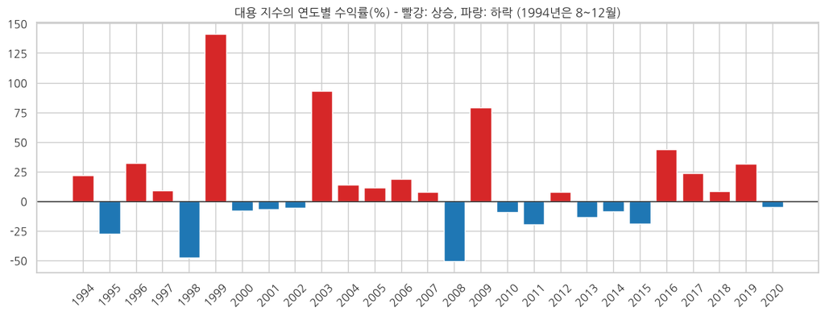

| ym | 1994 | 1995 | 1996 | 1997 | 1998 | 1999 | 2000 | 2001 | 2002 | 2003 | 2004 | 2005 | 2006 | 2007 | 2008 | 2009 | 2010 | 2011 | 2012 | 2013 | 2014 | 2015 | 2016 | 2017 | 2018 | 2019 | 2020 |
| --- | --- | --- | --- | --- | --- | --- | --- | --- | --- | --- | --- | --- | --- | --- | --- | --- | --- | --- | --- | --- | --- | --- | --- | --- | --- | --- | --- |
| 연수익률(%) | 21.5 | -27.4 | 32.3 | 9.1 | -47.8 | 141.1 | -8.3 | -6.9 | -5.9 | 93.2 | 13.7 | 11.3 | 18.9 | 7.7 | -50.8 | 78.8 | -9.1 | -20.0 | 7.5 | -13.8 | -8.5 | -18.9 | 43.8 | 23.3 | 8.4 | 31.3 | -5.0 |

```python
# 연도별 시장 수익률(%)
year_ret = (mkt['시장수익률'].groupby(mkt.index.year)
               .apply(lambda r: (1 + r).prod() - 1) * 100).round(1)

fig, ax = plt.subplots(figsize=(14, 4.5))
colors = np.where(year_ret >= 0, 'tab:red', 'tab:blue')
ax.bar(year_ret.index.astype(str), year_ret.values, color=colors)
ax.axhline(0, color='black', lw=0.8)
ax.set_title('대용 지수의 연도별 수익률(%) - 빨강: 상승, 파랑: 하락 (1994년은 8~12월)')
ax.tick_params(axis='x', rotation=45)
plt.show()

year_ret.to_frame('연수익률(%)').T
```

- 한줄 확인 : **1999년(+141.1%), 2003년(+93.2%), 2009년(+78.8%)** 에 크게 올랐고, **2008년(-50.8%), 1998년(-47.8%), 1995년(-27.4%)** 에 크게 떨어졌다.
  - 2011~2015년에는 2012년(+7.5%)을 빼고 매년 하락했다.

#### 지수와 금리·환율을 한눈에 (인터랙티브)

- 마우스를 올리면 값을 볼 수 있고, 범례를 클릭하면 선을 끄고 켤 수 있다. 회색 구간은 위기 구간.

```python
# 월말 기준 금리·환율
selic_m = selic.set_index('datetime')['연금리(%)'].resample('ME').last().to_period('M')
fx_m = fx.set_index('datetime')['usd_brl'].resample('ME').last().to_period('M')

crisis = {'2008 금융위기': ('2008-06', '2009-02'),
          '2015 브라질 경기침체': ('2015-01', '2015-12'),
          '2020 코로나': ('2020-01', '2020-04')}

x = mkt.index.to_timestamp()
fig = go.Figure()
fig.add_trace(go.Scatter(x=x, y=mkt['지수'], name='대용 지수(로그)', line=dict(color='firebrick')))
fig.add_trace(go.Scatter(x=x, y=selic_m.reindex(mkt.index), name='Selic 연금리(%)', yaxis='y2',
                         line=dict(color='seagreen')))
fig.add_trace(go.Scatter(x=x, y=fx_m.reindex(mkt.index), name='USD/BRL 환율', yaxis='y3',
                         line=dict(color='royalblue')))
for name, (s, e) in crisis.items():
    fig.add_vrect(x0=s, x1=e, fillcolor='gray', opacity=0.2, line_width=0,
                  annotation_text=name, annotation_position='top left')
fig.update_layout(title='대용 지수 vs Selic 금리 vs 환율 (월말)', height=500,
                  xaxis=dict(domain=[0, 0.85]),
                  yaxis=dict(title='지수(1994-07=100, 로그)', type='log'),
                  yaxis2=dict(title='Selic(%)', overlaying='y', side='right', position=0.85),
                  yaxis3=dict(title='USD/BRL', overlaying='y', side='right', anchor='free', position=0.95),
                  legend=dict(orientation='h', y=-0.15))
fig.show()
```

[interactive chart not shown]

- 한줄 확인 : 금리는 장기적으로 내려가고, 환율(USD/BRL)은 장기적으로 올라갔다(헤알화 약세). 회색 위기 구간마다 지수가 떨어지고 환율이 뛰는 모습이 보인다.

### 3. 금리·환율과 주가 수익률의 상관

- 수준(level)끼리 비교하면 둘 다 시간에 따라 움직이는 추세 때문에 상관이 과장된다.
- 그래서 **변화량**끼리 비교한다.
  - 주가 : 월 수익률(%)
  - 금리 : 월말 연금리의 **전월 대비 변화(%p)**
  - 환율 : USD/BRL의 **전월 대비 변화율(%)** (+면 헤알화 약세 = 달러 강세)

```python
df = pd.DataFrame({
    '주가수익률(%)': mkt['시장수익률'] * 100,
    '금리변화(%p)': selic_m.diff(),
    '환율변화(%)': fx_m.pct_change() * 100,
}).dropna()

# 1994~1999년 초는 고금리·고정환율 시기로 변동이 매우 크므로, 1999년 변동환율제 이후와 나누어 본다
df_all = df
df_99 = df[df.index >= '1999-03']
print('전체 기간 월 수:', len(df_all), '/ 1999-03 이후 월 수:', len(df_99))
df_all.describe().round(2)
```

```
전체 기간 월 수: 317 / 1999-03 이후 월 수: 262
```

|  | 주가수익률(%) | 금리변화(%p) | 환율변화(%) |
| --- | --- | --- | --- |
| count | 317.00 | 317.00 | 317.00 |
| mean | 0.80 | -0.22 | 0.70 |
| std | 8.15 | 3.34 | 5.96 |
| min | -36.95 | -24.49 | -16.60 |
| 25% | -3.55 | -0.50 | -1.96 |
| 50% | 0.43 | 0.00 | 0.46 |
| 75% | 6.05 | 0.04 | 2.43 |
| max | 24.85 | 22.02 | 64.08 |

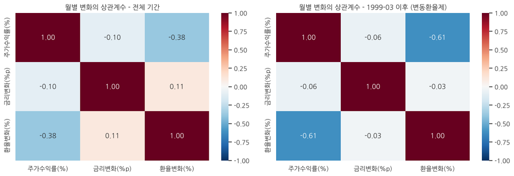

```python
fig, axes = plt.subplots(1, 2, figsize=(13, 4.5))
for ax, data, title in [(axes[0], df_all, '전체 기간'), (axes[1], df_99, '1999-03 이후 (변동환율제)')]:
    sns.heatmap(data.corr(), annot=True, fmt='.2f', cmap='RdBu_r', vmin=-1, vmax=1, ax=ax)
    ax.set_title(f'월별 변화의 상관계수 - {title}')
plt.tight_layout()
plt.show()
```

- 한줄 확인 : **환율 변화와 주가 수익률의 상관이 가장 강하다.** 1999-03 이후 **-0.61**, 전체 기간 -0.38
  - 달러가 강해지는(헤알화가 약해지는) 달에 브라질 주가는 떨어지는 경향이 있다.
  - 금리 변화와의 같은 달 상관은 -0.06(1999-03 이후), -0.10(전체)으로 약하다.

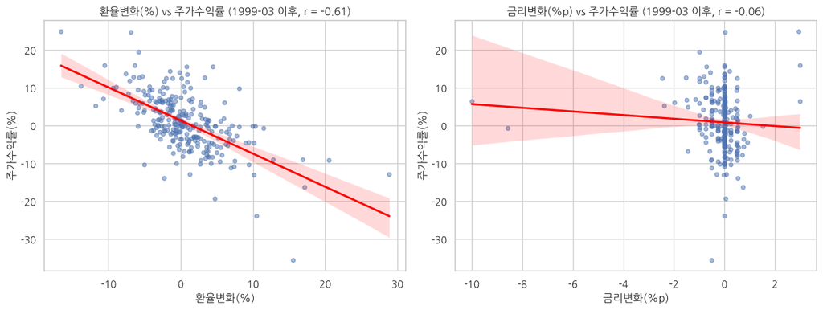

```python
fig, axes = plt.subplots(1, 2, figsize=(13, 5))
for ax, col in zip(axes, ['환율변화(%)', '금리변화(%p)']):
    sns.regplot(data=df_99, x=col, y='주가수익률(%)', ax=ax,
                scatter_kws={'alpha': 0.5, 's': 20}, line_kws={'color': 'red'})
    r = df_99[[col, '주가수익률(%)']].corr().iloc[0, 1]
    ax.set_title(f'{col} vs 주가수익률 (1999-03 이후, r = {r:.2f})')
plt.tight_layout()
plt.show()
```

- 한줄 확인 : 환율 쪽은 점들이 오른쪽 아래로 뚜렷하게 모여 있다.
  - 금리 쪽은 대부분의 달에 금리 변화가 0 근처(정책금리는 가끔만 바뀜)이고, 왼쪽의 큰 금리 인하 2개 점이 회귀선을 끌어당기고 있어 관계가 약하다.

### 4. 시차 상관 - 금리·환율이 주가를 "먼저" 움직일까?

- `k > 0` : **k개월 전**의 금리·환율 변화와 이번 달 주가 수익률의 상관 (금리·환율이 먼저 → 예측에 쓸 수 있음)
- `k < 0` : 주가가 먼저 움직이고 k개월 뒤 금리·환율이 따라가는 경우
- 표본이 약 260개일 때 상관계수가 대략 **±0.12** 를 넘어야 우연이 아니라고 볼 수 있다. (95% 기준, ±2/√n)

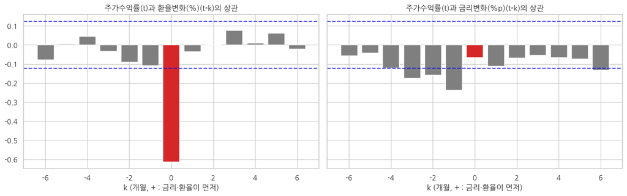

```
우연 범위 : ±0.124
```

| k(개월) | -6 | -5 | -4 | -3 | -2 | -1 | 0 | 1 | 2 | 3 | 4 | 5 | 6 |
| --- | --- | --- | --- | --- | --- | --- | --- | --- | --- | --- | --- | --- | --- |
| 환율변화(%) | -0.078 | 0.005 | 0.046 | -0.033 | -0.089 | -0.108 | -0.612 | -0.034 | 0.004 | 0.077 | 0.011 | 0.062 | -0.021 |
| 금리변화(%p) | -0.055 | -0.043 | -0.119 | -0.175 | -0.158 | -0.236 | -0.065 | -0.109 | -0.069 | -0.055 | -0.065 | -0.072 | -0.131 |

```python
lags = range(-6, 7)
lag_corr = pd.DataFrame({
    col: [df_99['주가수익률(%)'].corr(df_99[col].shift(k)) for k in lags]
    for col in ['환율변화(%)', '금리변화(%p)']
}, index=lags)
lag_corr.index.name = 'k(개월)'

bound = 2 / np.sqrt(len(df_99))
fig, axes = plt.subplots(1, 2, figsize=(14, 4.5), sharey=True)
for ax, col in zip(axes, lag_corr.columns):
    ax.bar(lag_corr.index, lag_corr[col], color=np.where(lag_corr.index == 0, 'tab:red', 'tab:gray'))
    ax.axhline(bound, ls='--', color='blue'); ax.axhline(-bound, ls='--', color='blue')
    ax.set_title(f'주가수익률(t)과 {col}(t-k)의 상관')
    ax.set_xlabel('k (개월, + : 금리·환율이 먼저)')
plt.tight_layout()
plt.show()

print(f'우연 범위 : ±{bound:.3f}')
lag_corr.round(3).T
```

- 한줄 확인 : **환율은 같은 달(k=0, -0.612)에만 강하게 연결**되고, 다른 시차는 모두 우연 범위(±0.124) 안이다. → 지난달 환율로 이번 달 주가를 맞히기는 어렵다.
  - 금리는 **k = -1, -2, -3**(주가가 먼저, 금리가 나중)에서 -0.236, -0.158, -0.175로 우연 범위를 벗어난다. 주가가 떨어진 뒤 1~3개월 안에 금리가 오르는 경향(위기 대응·물가 대응)으로 볼 수 있다.
  - 금리가 먼저인 k > 0 쪽은 k=6(-0.131)만 경계를 살짝 넘고 나머지는 우연 범위 안이다.

```python
# 주가 수익률 자신의 시차 상관(자기상관) - 지난달 수익률로 이번 달을 맞힐 수 있을까?
auto = pd.Series({k: df_99['주가수익률(%)'].autocorr(k) for k in range(1, 7)}, name='자기상관')
auto.round(3).to_frame().T
```

|  | 1 | 2 | 3 | 4 | 5 | 6 |
| --- | --- | --- | --- | --- | --- | --- |
| 자기상관 | 0.143 | -0.061 | -0.009 | -0.021 | -0.041 | 0.061 |

- 한줄 확인 : 1개월 자기상관이 0.143으로 우연 범위를 살짝 넘지만(약한 모멘텀), 설명력으로 보면 약 2%(0.143²)에 불과하다. 2개월 이후는 모두 0에 가깝다.

### 5. 변동성과 위기 구간 (2008, 2015, 2020)

- 변동성 = 수익률의 표준편차. 월 수익률의 표준편차 × √12 로 **연율화**한다.
- 12개월 **롤링 표준편차**로 시간에 따른 변화를 본다.

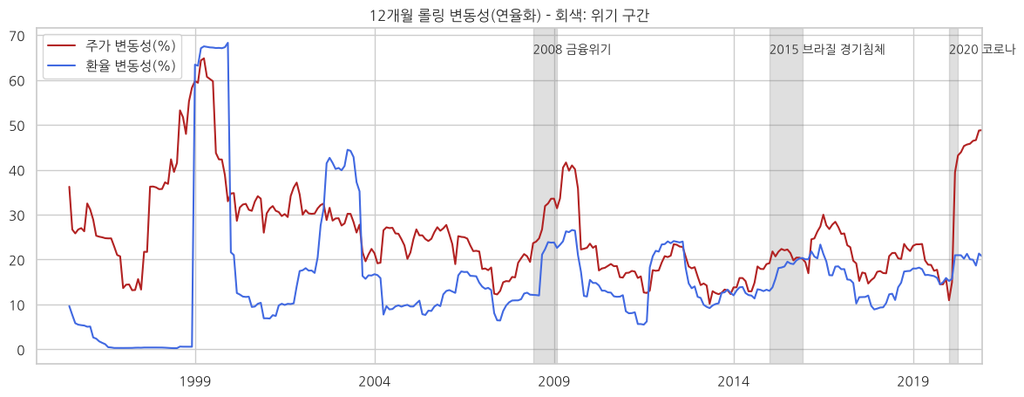

```python
vol = pd.DataFrame({
    '주가 변동성(%)': df['주가수익률(%)'].rolling(12).std() * np.sqrt(12),
    '환율 변동성(%)': df['환율변화(%)'].rolling(12).std() * np.sqrt(12),
})

fig, ax = plt.subplots(figsize=(14, 5))
vol.index = vol.index.to_timestamp()
vol.plot(ax=ax, color=['firebrick', 'royalblue'])
for name, (s, e) in crisis.items():
    ax.axvspan(pd.Timestamp(s), pd.Timestamp(e) + pd.offsets.MonthEnd(0), color='gray', alpha=0.25)
    ax.text(pd.Timestamp(s), ax.get_ylim()[1] * 0.92, name, fontsize=10)
ax.set_title('12개월 롤링 변동성(연율화) - 회색: 위기 구간')
ax.set_xlabel('')
plt.show()
```

- 한줄 확인 : 1998~1999년(아시아·러시아 위기, 1999년 헤알화 변동환율제 전환) 주가·환율 변동성이 모두 60%를 넘는 가장 큰 구간이었다.
  - 2008년 금융위기 직후 주가 변동성이 약 40%까지, 2020년 코로나 이후 약 49%까지 올랐다.
  - 12개월 롤링이므로 변동성 상승은 위기 구간보다 조금 늦게 나타난다.

```python
# 연도별 변동성(연율화 %)과 연수익률
year_tbl = pd.DataFrame({
    '연수익률(%)': year_ret,
    '주가 변동성(%)': df['주가수익률(%)'].groupby(df.index.year).std() * np.sqrt(12),
    '환율 변화(%)': fx_m.groupby(fx_m.index.year).last().pct_change() * 100,
    'Selic 연말(%)': selic_m.groupby(selic_m.index.year).last(),
}).round(1)
year_tbl.loc[[1998, 2002, 2007, 2008, 2009, 2014, 2015, 2016, 2019, 2020]]
```

|  | 연수익률(%) | 주가 변동성(%) | 환율 변화(%) | Selic 연말(%) |
| --- | --- | --- | --- | --- |
| 1998 | -47.8 | 58.3 | 8.3 | 29.0 |
| 2002 | -5.9 | 29.2 | 52.3 | 24.9 |
| 2007 | 7.7 | 16.0 | -17.2 | 11.2 |
| 2008 | -50.8 | 33.5 | 31.9 | 13.7 |
| 2009 | 78.8 | 22.6 | -25.5 | 8.7 |
| 2014 | -8.5 | 19.0 | 13.4 | 11.6 |
| 2015 | -18.9 | 20.2 | 47.0 | 14.2 |
| 2016 | 43.8 | 27.2 | -16.5 | 13.6 |
| 2019 | 31.3 | 15.7 | 4.0 | 4.4 |
| 2020 | -5.0 | 48.8 | 28.9 | 1.9 |

- 한줄 확인 : 2008년 **-50.8%** (변동성 33.5%, 환율 +31.9%), 2015년 **-18.9%** (환율 +47.0%, Selic 14.2%), 2020년 -5.0%였지만 **변동성은 48.8%** 로 표의 연도 중 1998년(58.3%) 다음으로 크다.
  - 2002년은 환율이 +52.3% 올랐지만 주가는 -5.9%로, 환율이 크게 올라도 매번 주가가 크게 떨어지는 것은 아니다.

```python
# 위기 구간 vs 평상시 : 평균 수익률, 변동성, 환율과의 상관
df_c = df_99.copy()
df_c['구간'] = '평상시'
for name, (s, e) in crisis.items():
    df_c.loc[(df_c.index >= s) & (df_c.index <= e), '구간'] = '위기 구간'

df_c.groupby('구간').apply(lambda d: pd.Series({
    '월 수': len(d),
    '평균 수익률(%)': d['주가수익률(%)'].mean(),
    '변동성(연율 %)': d['주가수익률(%)'].std() * np.sqrt(12),
    '환율과의 상관': d['주가수익률(%)'].corr(d['환율변화(%)']),
})).round(2)
```

| 구간 | 월 수 | 평균 수익률(%) | 변동성(연율 %) | 환율과의 상관 |
| --- | --- | --- | --- | --- |
| 위기 구간 | 25.0 | -4.56 | 36.17 | -0.47 |
| 평상시 | 237.0 | 1.51 | 23.67 | -0.61 |

- 한줄 확인 : 위기 구간(25개월)의 평균 월 수익률은 **-4.56%**, 평상시(237개월)는 **+1.51%**
  - 변동성은 위기 구간 **36.2%** 로 평상시(23.7%)의 약 1.5배
  - 환율과의 상관은 위기 구간 -0.47, 평상시 -0.61로 위기 때 더 강해지지는 않았다. (위기 구간은 25개월로 표본이 적음)

```python
# 위기 구간별 지수 누적 수익률과 환율 변화
rows = []
for name, (s, e) in crisis.items():
    r = mkt.loc[s:e, '시장수익률']
    rows.append([name, f'{s} ~ {e}', ((1 + r).prod() - 1) * 100, r.min() * 100,
                 (fx_m[e] / fx_m[pd.Period(s) - 1] - 1) * 100])
pd.DataFrame(rows, columns=['위기', '기간', '지수 누적 수익률(%)', '최악의 달(%)', '환율 변화(%)']).round(1)
```

|  | 위기 | 기간 | 지수 누적 수익률(%) | 최악의 달(%) | 환율 변화(%) |
| --- | --- | --- | --- | --- | --- |
| 0 | 2008 금융위기 | 2008-06 ~ 2009-02 | -52.5 | -23.8 | 46.0 |
| 1 | 2015 브라질 경기침체 | 2015-01 ~ 2015-12 | -18.9 | -9.3 | 47.0 |
| 2 | 2020 코로나 | 2020-01 ~ 2020-04 | -31.0 | -35.4 | 34.6 |

- 한줄 확인 : 2008 금융위기 9개월간 **-52.5%**, 2020 코로나 4개월간 **-31.0%** (2020년 3월 한 달 -35.4%), 2015년 1년간 -18.9%
  - 세 위기 모두 환율이 **35~47% 상승**(헤알화 급락)했다.

### 6. 등락 예측 다시 보기 - 주가 예측이 어려운 이유

#### 6-1. 정답 누수(leakage) 확인

- 기본 분석의 정답 : `stock_up = 1 if close > open`
- 입력 : `open, close, high, low, volume` → **`close`와 `open`이 입력에 있으면 정답을 계산할 수 있다.**
- 실제로 **장이 열리는 시점**(시가를 알게 된 때)에 쓸 수 있는 정보만으로 다시 예측해 본다.
  - 오늘 시가(`open`), **어제** 종가·거래대금, 어제 대비 시가 변화율(갭)
- 기본 분석과 같이 깊이 제한 없는 의사결정트리를 사용한다.
- 계산 시간을 줄이기 위해 2010년 이후 데이터에서 30만 행을 표본 추출하고, 앞 70% 기간으로 학습 / 뒤 30% 기간으로 평가한다.

```python
from sklearn.tree import DecisionTreeClassifier

d = stock[stock['datetime'] >= '2010-01-01'].sort_values(['ticker', 'datetime']).copy()
gd = d.groupby('ticker', observed=True)
d['prev_close'] = gd['close'].shift(1)
d['prev_volume'] = gd['volume'].shift(1)
d['gap(%)'] = (d['open'] / d['prev_close'] - 1) * 100
d['stock_up'] = (d['close'] > d['open']).astype(int)
d = d.dropna().sample(300_000, random_state=42).sort_values('datetime')

cut = d['datetime'].quantile(0.7)
train, test = d[d['datetime'] <= cut], d[d['datetime'] > cut]
print('학습:', len(train), '/ 평가:', len(test), '/ 기준 날짜:', cut.date())

feature_sets = {
    '기본 분석 방식 (open, close 포함)': ['open', 'close', 'high', 'low', 'volume'],
    '장 시작 시점 정보만 (open, 어제 정보)': ['open', 'prev_close', 'prev_volume', 'gap(%)'],
}
rows = []
for name, cols in feature_sets.items():
    m = DecisionTreeClassifier(random_state=42).fit(train[cols], train['stock_up'])
    rows.append([name, m.score(train[cols], train['stock_up']), m.score(test[cols], test['stock_up'])])

base = 1 - test['stock_up'].mean()   # 항상 '안 오름(0)'으로 찍었을 때
rows.append(['항상 "오르지 않음"으로 찍기', np.nan, base])
pd.DataFrame(rows, columns=['입력 변수', '학습 정확도', '평가 정확도']).round(3)
```

```
학습: 210120 / 평가: 89880 / 기준 날짜: 2018-04-09
```

|  | 입력 변수 | 학습 정확도 | 평가 정확도 |
| --- | --- | --- | --- |
| 0 | 기본 분석 방식 (open, close 포함) | 1.000 | 0.894 |
| 1 | 장 시작 시점 정보만 (open, 어제 정보) | 0.998 | 0.556 |
| 2 | 항상 "오르지 않음"으로 찍기 | NaN | 0.615 |

- 한줄 확인 : **open과 close를 함께 넣으면 평가 정확도 89.4%**, 장 시작 시점에 알 수 있는 정보만 쓰면 **55.6%** 로 떨어진다.
  - 55.6%는 "항상 오르지 않음"으로 찍는 61.5%보다도 낮다. 학습 정확도(99.8%)와의 차이는 **과대적합**
  - 기본 분석의 97.2%는 **정답 누수 + 무작위 분할(같은 날짜가 학습·평가에 섞임) + 더 큰 학습 데이터**에서 나온 결과로, 실제로는 쓸 수 없는 정확도이다.

```python
# 정답 분포 : close == open(가격 변화 없음)인 날이 많다
pd.Series({
    '오름(close > open)': (d['close'] > d['open']).mean(),
    '같음(close = open)': (d['close'] == d['open']).mean(),
    '내림(close < open)': (d['close'] < d['open']).mean(),
}).mul(100).round(1).to_frame('비율(%)').T
```

|  | 오름(close > open) | 같음(close = open) | 내림(close < open) |
| --- | --- | --- | --- |
| 비율(%) | 38.8 | 19.5 | 41.6 |

- 한줄 확인 : 가격 변화가 없는 날(close = open)이 **19.5%**. 기본 분석은 이를 "내림(0)"으로 묶어서 "오르지 않음"이 61.1%가 되어, 찍기만 해도 60% 이상이 나오는 불균형 문제가 있다.

#### 6-2. 금리·환율로 다음 달 시장 등락을 맞힐 수 있을까?

- 이번 달까지의 주가 수익률, 금리 변화, 환율 변화로 **다음 달 지수가 오를지** 예측 (로지스틱 회귀)
- 시간 순서를 지켜 **2014년까지 학습, 2015~2020년 평가**

```python
from sklearn.linear_model import LogisticRegression

X = df_99[['주가수익률(%)', '금리변화(%p)', '환율변화(%)']]
y = (df_99['주가수익률(%)'].shift(-1) > 0).astype(int)   # 다음 달 상승 여부
X, y = X.iloc[:-1], y.iloc[:-1]

tr, te = X.index < '2015-01', X.index >= '2015-01'
logit = LogisticRegression().fit(X[tr], y[tr])

print('평가 기간 월 수:', te.sum())
print('로지스틱 회귀 평가 정확도 :', round(logit.score(X[te], y[te]), 3))
print('항상 "상승"으로 찍기       :', round(y[te].mean(), 3))
print('계수:', dict(zip(X.columns, logit.coef_[0].round(3))))
```

```
평가 기간 월 수: 71
로지스틱 회귀 평가 정확도 : 0.465
항상 "상승"으로 찍기       : 0.521
계수: {'주가수익률(%)': np.float64(0.043), '금리변화(%p)': np.float64(-0.068), '환율변화(%)': np.float64(0.034)}
```

- 한줄 확인 : 2015~2020년 71개월 평가에서 정확도 **46.5%** 로, "항상 상승"으로 찍는 52.1%보다 낮다. 같은 달 상관이 강했던 환율도 **다음 달**을 맞히는 데는 도움이 되지 않았다.

#### 6-3. 주가 예측이 어려운 이유

- **정답 누수** : 예측 시점에 알 수 없는 정보(오늘 종가)를 입력에 넣으면 정확도가 비현실적으로 높아진다. → 기본 분석의 97.2%
- **이미 가격에 반영됨** : 금리·환율 변화는 발표되는 순간 주가에 함께 반영된다. 같은 달 상관은 뚜렷하지만(동시 상관), 지난달 값으로 이번 달을 맞히는 힘(시차 상관)은 약하다.
- **잡음이 크다** : 월 수익률의 자기상관이 0에 가깝고, 변동성은 위기 때 몇 배로 커진다. 평균적인 관계가 위기 때는 달라진다.
- **추세 외삽의 위험** : Prophet처럼 한 종목의 과거 추세를 그대로 늘리면 음수 주가 같은 불가능한 값도 나온다.

### 7. 정리

| 질문 | 기본 분석 | 추가 분석 결과 |
| --- | --- | --- |
| 시장 전체의 흐름은? | 종목 하나(ALP 3)만 확인 | 거래대금 상위 50종목 동일가중 지수 : 1994-07=100 → 2020-12 약 425. 2008년 -50.8%, 1998년 -47.8%, 1999년 +141.1% |
| 금리·환율과 주가의 관계는? | 데이터를 불러오기만 함 | 같은 달 기준 **환율 변화와 -0.61**(1999-03 이후)로 강한 음의 상관, 금리 변화와는 -0.06으로 약함 |
| 금리·환율이 주가를 미리 알려줄까? | - | 환율은 시차 상관이 모두 우연 범위(±0.124) 안. 금리는 오히려 **주가가 먼저** 떨어지고 1~3개월 뒤 금리가 오르는 경향(-0.16 ~ -0.24) |
| 위기 때 무엇이 달라질까? | - | 위기 구간 변동성 36.2% vs 평상시 23.7%(약 1.5배). 2008년 -52.5%, 2020년 -31.0%, 세 위기 모두 환율 35~47% 급등 |
| 등락 예측 정확도 97.2%는 믿을 만한가? | 의사결정트리 97.2% | 정답 누수. 장 시작 시점 정보만 쓰면 **55.6%** 로 찍기(61.5%)보다 낮음. 금리·환율로 다음 달 시장 등락 예측도 46.5% < 찍기 52.1% |

#### 배운 점

- 수천 개 종목도 **거래대금 상위 종목의 평균 수익률**로 간단한 시장 지수를 만들어 흐름을 볼 수 있다.
- 시계열끼리는 수준이 아니라 **변화량**으로 상관을 보고, **시차 상관**으로 "먼저 움직이는지"를 따로 확인해야 한다.
- 예측 모델은 **예측 시점에 알 수 있는 정보만** 입력으로 쓰고, **시간 순서대로** 나누어 평가하며, **단순 기준(항상 같은 답)** 과 비교해야 한다.

#### 다음에 해 볼 분석

- 실제 Ibovespa 지수, 원자재(철광석·원유) 가격, 미국 금리 등 외부 변수 추가
- 종목별 베타(시장 민감도), 환율 민감도 계산 → 수출주/내수주 비교
- GARCH 같은 변동성 모델로 위기 구간 변동성 예측